# Distribución de las variantes de SARS-CoV-2 en las entidades federativas más pobladas de México

Ortiz Ávila Emilio and Camacho Santana Luis Gerardo

First Author's Affiliation

28 mayo 2021

# Contents

¿Cómo es la evolución de SARS-CoV-2 en los estados más poblados de México?

# 1 Importar secuencias de GISAID

Las secuencias de los genomas de `SARS-CoV-2` fueron recuperadas de la plataforma `GISAID`, 20 secuencias de las 10 entidades federativas más pobladas de México, y del genoma de referencia de Wuhan, contando con un total de 201. Las entidades federativas más pobladas de México son: Estado de México, CDMX, Jalisco, Veracruz, Puebla, Guanajuato, Nuevo León, Chiapas, Michoacan y Oaxaca.

```r
setwd("C:/Users/52442/Desktop/Proyecto_genomica/") #Directorio en donde se tienen las secuencias
memory.size(max = T) #Optimizar el uso de la
```

```
## [1] 48.88
```

```r
library(Biostrings)
library(msa)

hCoV19_Mexico <- readDNAStringSet(c("Wuhan_refseq.fasta","1_Estado_de_Mexico.fasta", "2_CDMX.fasta",
                                    "3_Jalisco.fasta", "4_Veracruz.fasta", "5_Puebla.fasta",
                                    "6_Guanajuato.fasta", "7_Nuevo_Leon.fasta", "8_Chiapas.fasta",
                                    "9_Michoacan.fasta", "10_Oaxaca.fasta"))
```

# 2 Alinear secuencias con MAFFT

`MAFFT` (Multiple sequence alignment based on Fast Fourier Transform) es un programa que implementa un algoritmo de alineamiento multiple utilizando FFT (Fast Fourier Transform).

`MAFFT` se clasifica en tres tipos, (a) un metodo progresivo, (b) método de refinamiento iterativo con el WSP-score y (c), método de refinamiento iterativo con el WSP-score y de consistencias.

*Weighted sum of pairs (WSP-score): add all pairwise alignment scores and contributions form groups of very similar sequences are down.weighted*

Velociad: a > b > c Precisión: a < b < c

Las regiones homólogas son identificadas por la `FFT`, reduce el tiempo de la CPU e incrementa la precisión de los alineamientos.

Descargar el paquete MAFFT desde Ubuntu

```bash
# wget https://mafft.cbrc.jp/alignment/software/mafft_7.480-1_amd64.deb
```

Instalar el paquete

```bash
# sudo dpkg -i mafft_7.480-1_amd64.deb  Copy to clipboard
# [sudo] password for username:  Aquí es donde te debes de recordar de tu contraseña
```

Checar la localización y la versión de `MAFFT`

```bash
# which mafft
# /usr/bin/mafft

# mafft --version
# v7.480 (2021/May/21)
```

Una vez que el paquete se haya instalado, entonces podemos utilizar una librería llamada `rMSA` para poder acceder al software recien instalado y realizar el alineamiento múltiple con `MAFFT`.

```r
# install.packages("remotes")
# remotes::install_github("mhahsler/rMSA", force = T)

library("rMSA")
Mafft_aln <- mafft(x = hCoV19_Mexico)

# save(Mafft_aln, file = "Mafft_aln.RData")
```

# 3 PIS - Parsimony informative sites

PIS son fragmentos o zonas de las secuencias que pueden ser utilizadas para distinguir entre muestras a nivel genetico.

```r
#install.packages("ips")
load("Mafft_aln.RData")
library(ips)

PI_1 <- as.DNAbin(Mafft_aln)

PI_1_abs <- pis(PI_1, what = "abs", use.ambiguities = FALSE) # Cuantos sitios hay
PI_1_ind <- pis(PI_1, what = "ind", use.ambiguities = FALSE) # En que posiciones del alineamiento


PI_1_abs # Hay 478 sitios informativos
```

```
## [1] 478
```

```r
PI_1_ind # Las posiciones
```

```
##   [1]    78   100   106   201   203   210   222   241   275   277   337   497
##  [13]   683   733   745   866   913   936   942   994  1009  1059  1191  1327
##  [25]  1342  1376  1417  1419  1513  1521  1567  1623  1738  1889  1912  1913
##  [37]  1968  2010  2061  2086  2164  2395  2442  2453  2497  2509  2536  2597
##  [49]  2698  2716  2749  3037  3120  3140  3165  3267  3351  3411  3429  3444
##  [61]  3454  3477  3581  3688  3692  3728  3745  3753  3766  3828  3856  3871
##  [73]  3874  3884  3885  3903  3904  4021  4087  4181  4201  4296  4339  4406
##  [85]  4543  4763  5144  5157  5183  5184  5234  5388  5488  5584  5619  5648
##  [97]  5672  5680  5694  5748  5812  5835  5869  5878  5934  5974  5986  6027
## [109]  6037  6040  6070  6266  6319  6336  6402  6445  6555  6586  6613  6627
## [121]  6633  6638  6717  6720  6954  7037  7124  7142  7420  7521  7737  7765
## [133]  7829  8123  8293  8299  8344  8480  8622  8782  8947  8986  9053  9070
## [145]  9120  9430  9438  9456  9477  9559  9587  9611  9614  9693  9711  9738
## [157]  9754  9756  9891  9924  9935 10029 10156 10186 10323 10667 10954 10982
## [169] 11005 11020 11083 11117 11124 11197 11201 11283 11296 11332 11365 11418
```

[output cut: 25 more lines]

```r
library(ape)
Mafft_aln_nogaps <- deleteGaps(PI_1, gap.max = nrow(PI_1)-4) # Eliminamos todos los gaps

# Comparamos las dimensiones antes y después de remover los gaps
dim(Mafft_aln)
```

```
## [1]   201 29925
```

```r
dim(Mafft_aln_nogaps)
```

```
## [1]   201 29877
```

```r
PI_2_abs <- pis(Mafft_aln_nogaps, what = "abs", use.ambiguities = FALSE) # Cuantos sitios hay
PI_2_ind <- pis(Mafft_aln_nogaps, what = "ind", use.ambiguities = FALSE) # En que posiciones del alineamiento

PI_2_abs # Hay 478 sitios informativos
```

```
## [1] 478
```

```r
PI_2_ind # Las posiciones
```

```
##   [1]    48    70    76   171   173   180   192   211   245   247   307   467
##  [13]   653   703   715   836   883   906   912   964   979  1029  1161  1297
##  [25]  1312  1346  1387  1389  1483  1491  1537  1593  1708  1859  1882  1883
##  [37]  1938  1980  2031  2056  2134  2365  2412  2423  2467  2479  2506  2567
##  [49]  2668  2686  2719  3007  3090  3110  3135  3237  3321  3381  3399  3414
##  [61]  3424  3447  3551  3658  3662  3698  3715  3723  3736  3798  3826  3841
##  [73]  3844  3854  3855  3873  3874  3991  4057  4151  4171  4266  4309  4376
##  [85]  4513  4733  5114  5127  5153  5154  5204  5358  5458  5554  5589  5618
##  [97]  5642  5650  5664  5718  5782  5805  5839  5848  5904  5944  5956  5997
## [109]  6007  6010  6040  6236  6289  6306  6372  6415  6525  6556  6583  6597
## [121]  6603  6608  6687  6690  6924  7007  7094  7112  7390  7491  7707  7735
## [133]  7799  8093  8263  8269  8314  8450  8592  8752  8917  8956  9023  9040
## [145]  9090  9400  9408  9426  9447  9529  9557  9581  9584  9663  9681  9708
## [157]  9724  9726  9861  9894  9905  9999 10126 10156 10293 10637 10924 10952
## [169] 10975 10990 11053 11087 11094 11167 11171 11253 11266 11302 11335 11388
```

[output cut: 25 more lines]

```r
PI_hCoV19 <- Mafft_aln_nogaps[ , c(PI_2_ind)] # Seleccionamos del alineamiento solamente los sitios informativos
```

```r
# Asignamos nombres a las secuencias que ahora tenemos
Estados <- c("Wuh", paste0("E_Mex_", seq("1", "20")), paste0("CDMX_", seq("1", "20")),
             paste0("Jal_", seq("1", "20")), paste0("Ver_", seq("1", "20")),
             paste0("Pue_", seq("1", "20")), paste0("Gua_", seq("1", "20")),
             paste0("NL_", seq("1", "20")), paste0("Chi_", seq("1", "20")),
             paste0("Mich_", seq("1", "20")), paste0("Oax_", seq("1", "20")))

rownames(PI_hCoV19) <- Estados

# write.nexus.data(PI_hCoV19, file = "PI_hCoV19.nex")
# write.FASTA(PI_hCoV19, file = "PI_hCoV19.fa")
```

# 4 Análisis de cluster

Con el archivo `FASTA` previamente creado de los `IPS` se realizó una matriz de distancias

```r
library(seqinr)
library(msa)

PI_hCoV19 <- readDNAMultipleAlignment("PI_hCoV19.fa")

PI_hCoV19 <- msaConvert(PI_hCoV19, type="seqinr::alignment")

D <- dist.alignment(PI_hCoV19, "similarity")
```

Posteriormente, se hizó un análisis de cluster para observar de manera gráfica como las secuencias se agrupan

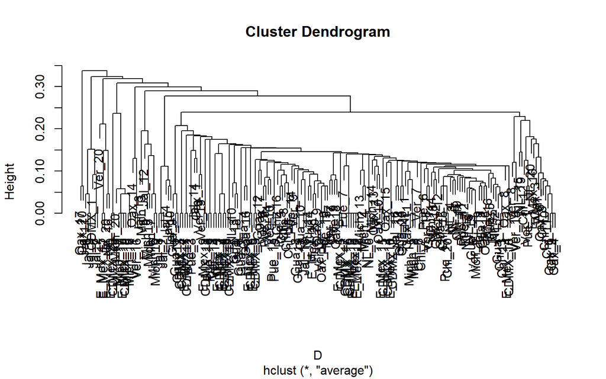

```r
Dendograma <- hclust(D, "average")
plot(Dendograma)
```

```r
Dendo <- as.phylo(Dendograma)
# write.tree(phy = Dendo, file="Dendo.newick")
```

El dendograma creado es exportado para mejorar su visualización en `Figtree`

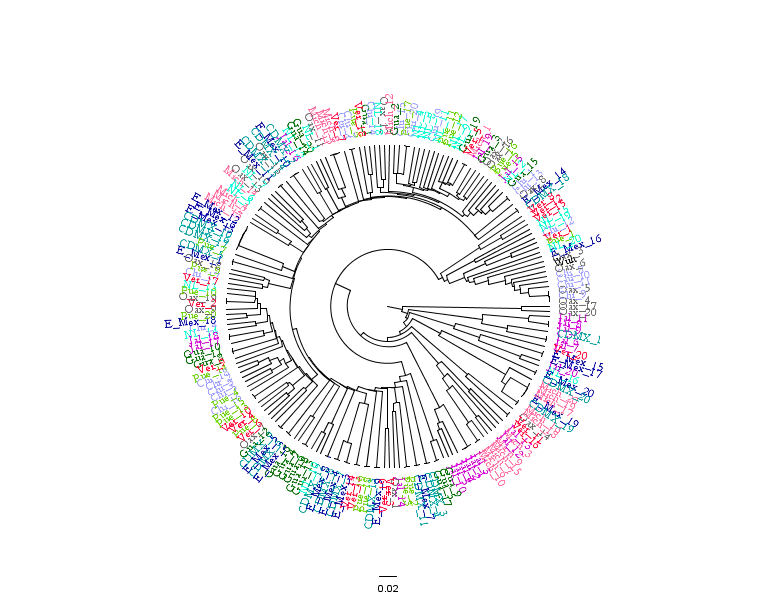

```r
# install.packages("png")
library(png)
knitr::include_graphics("Figtree_IPS.png")
```

# 5 MDS

`MDS` es una técnica de reducción de la dimensionalidad para proyectar en dos dimensiones las distancias relativas de, en este caso, las secuencias de los 10 estados de México.

```r
# install.packages("bios2mds")
library(bios2mds)

PI_hCoV19 <- import.fasta("PI_hCoV19.fa") # Importar las secuencias de los PIS

# Se crea una base de datos donde se tenga informacion acerca de que secuencia pertenece a que grupo (estado) y el color que se le será asignado para visualizarlos en el plot.

Estados <- c("Wuh", paste0("E_Mex_", seq("1", "20")), paste0("CDMX_", seq("1", "20")),
             paste0("Jal_", seq("1", "20")), paste0("Ver_", seq("1", "20")),
             paste0("Pue_", seq("1", "20")), paste0("Gua_", seq("1", "20")),
             paste0("NL_", seq("1", "20")), paste0("Chi_", seq("1", "20")),
             paste0("Mich_", seq("1", "20")), paste0("Oax_", seq("1", "20")))

Nombres <- Estados

Estados <- c("Wuh", rep("E_Mex", 20), rep("CDMX", 20),
             rep("Jal", 20), rep("Ver", 20), rep("Pue", 20),
             rep("Gua", 20), rep("NL", 20), rep("Chi", 20),
             rep("Mich", 20), rep("Oax", 20))

Colores <- c("blue", rep("turquoise", 20), rep("purple3", 20),
             rep("mediumspringgreen", 20), rep("lightpink1", 20), rep("sienna1", 20),
             rep("magenta", 20), rep("darkred", 20), rep("navyblue", 20),
             rep("darkgoldenrod1", 20), rep("lightcoral", 20))

# Agregamos comillas a todos los elementos que se encuentran een los objetos
Nombres <- sapply(Nombres, function(x) gsub("\"", "", x))
Estados <- sapply(Estados, function(x) gsub("\"", "", x))
Colores <- sapply(Colores, function(x) gsub("\"", "", x))


Grupos <- cbind(Nombres, Estados, Colores)
Grupos <- Grupos[ ,-1] # Quitamos una columna extra
# write.csv(Grupos, file = "Grupos.csv")
```

Con el archivo `csv` creado, de manera manual se quitó el primer renglon y se importó para realizar el `MDS`

[figure not shown]

```r
Dist_mat <- mat.dif(PI_hCoV19, PI_hCoV19)
mmds_hCoV19 <- mmds(Dist_mat, group.file = "C:/Users/52442/Desktop/Proyecto_genomica/Grupos.csv")

scree.plot(mmds_hCoV19$eigen.perc, lab = TRUE, title = "PIS de hCoV19")
knitr::include_graphics("scree.plot.png")
```

Este es un plot de los tres componentes principales que explican el mayor porcentaje de la variación. El primer componente explica eñ 32.8%, el segundo componente el 14.732% y el tercero el 9.143%.

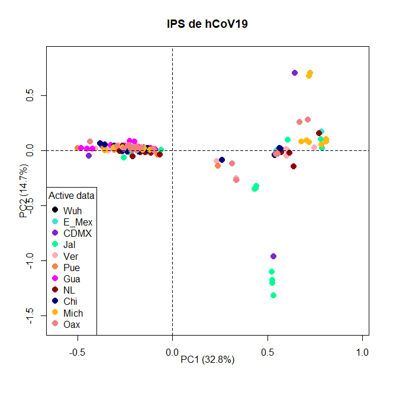

```r
mmds.2D.plot(mmds_hCoV19, title = "IPS de hCoV19")
knitr::include_graphics("mmds.2D.png")
```

Se hizo una representación con los dos primeros componentes principales, los cuales juntos explican un 47.5% de la variación.

```r
mmds.3D.plot(mmds_hCoV19, title = "IPS de hCoV19")
```

[output not shown]

Tambien se pueden tomar en cuenta el tercer componente principal para hacer un plot de tres dimensiones

# 6 Redes

Se exportó un archivo nexus con el alineamiento de las secuencias, a este archivo se añadieron etiquetas de los lugares donde se obtuvieron las secuencias, para así poder generar una red en la que los nodos pudieran ser distinguidos entre si por el color que se les asignó con base en el estado donde se obtuvieron.

Dicha red muestra nodos que contienen un determinado numero de secuencias, el tamaño de los nodos es proporcional al numero de secuencias que contiene, lo que sugiere que tales secuencias son, en esencia, idénticas y las conexiones entre cada par de nodos muestra los cambios o mutaciones de nucleótidos que hay entre estos nodos; es decir, si el vértice que une a dos nodos presenta un valor de 3, significa que esas dos secuencias difieren en tres nucleótidos.

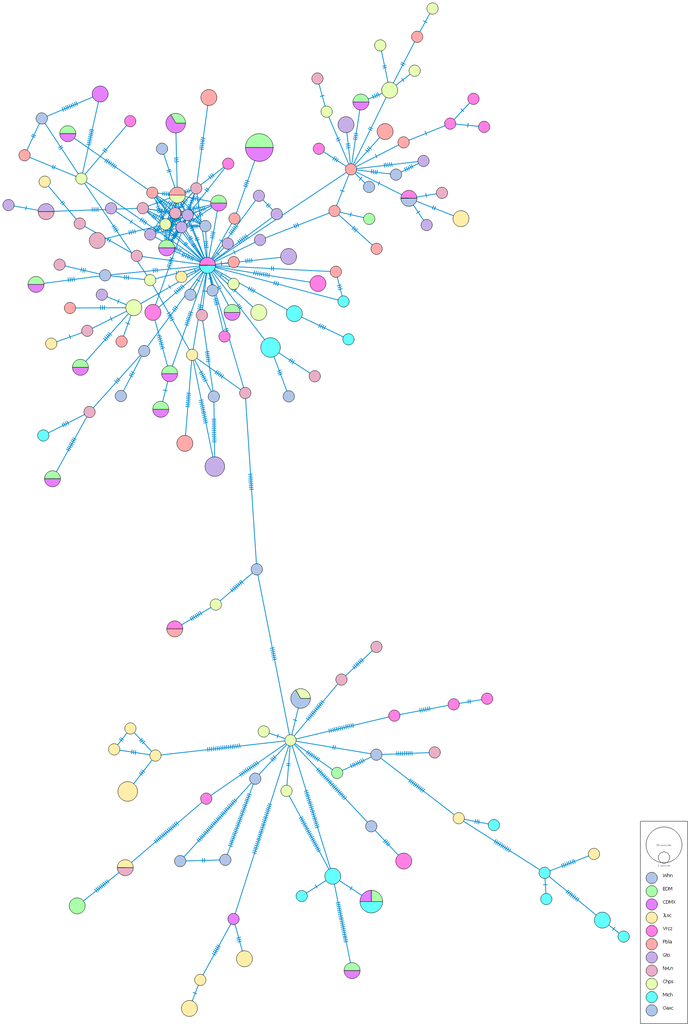

```r
knitr::include_graphics("Poptart2.png")
```

Tajima’s D es un estadístico de genética poblacional que se calcula a partir de secuencias nucleotidicas. Se usa comúnmente para estimar si ciertos supuestos se cumplen en una población o conjunto de secuencias. Uno de estos supuestos es el de Evolución neutral, que indica si existe o no una significancia evolutiva en las secuencias que se trabajan.

D=-2.22035

Un valor negativo del estadístico Tajima’s D sugiere que existe significancia de los PIS en la evolución de estos genomas.

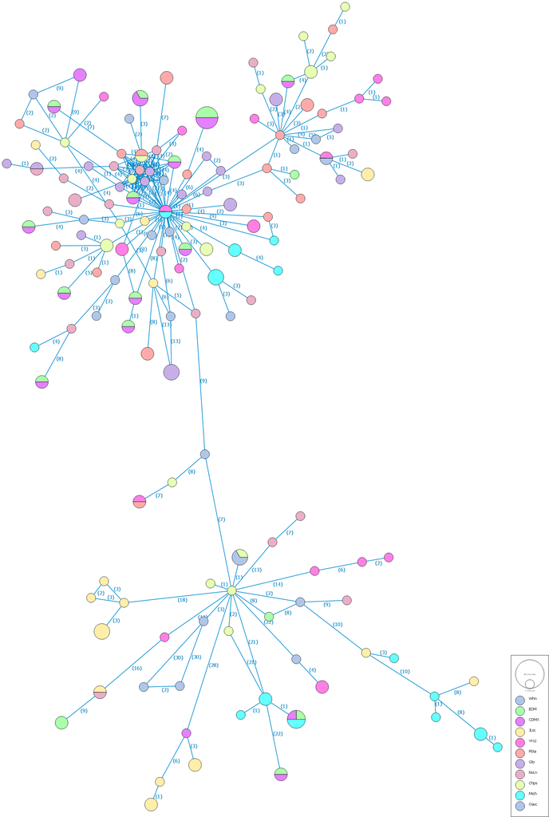

```r
knitr::include_graphics("Poptart.png")
```

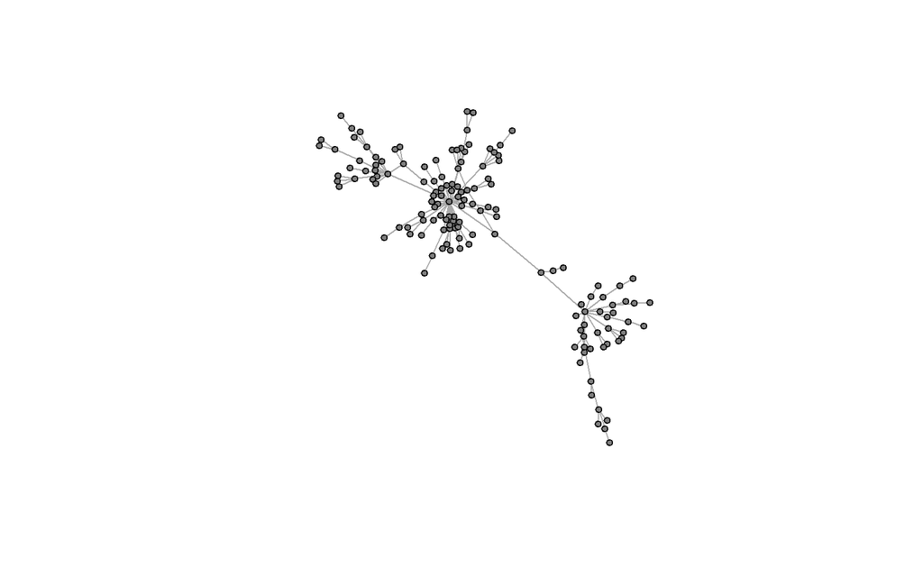

```r
library(igraph)
Ady_list <- read.table("FinalytalTABLE.txt")[ ,c(-2)]
Ady_list <- as.matrix(Ady_list)

colnames(Ady_list) <- c("V1", "V2")



Red_popart <- graph_from_edgelist(Ady_list, directed = F)
layout <- layout.fruchterman.reingold(Red_popart)
plot(Red_popart, layout = layout, vertex.size = 4,
     vertex.label = NA, edge.arrow.size = .1, vertex.color="gray50")
```

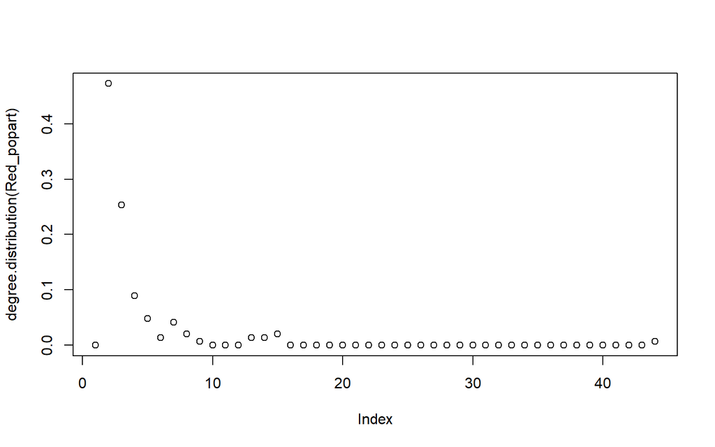

```r
plot(degree.distribution(Red_popart))
```

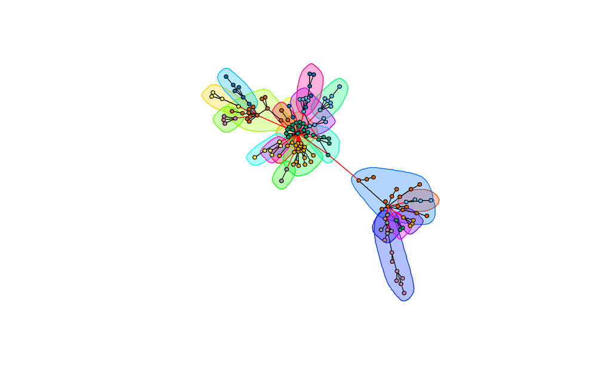

```r
eb <- edge.betweenness.community(Red_popart)
lb <- label.propagation.community(Red_popart)
cs <- cluster_spinglass(Red_popart)

plot(eb, Red_popart, layout = layout, vertex.size = 4,
     vertex.label = NA, edge.arrow.size = .1, vertex.color="gray50")
```

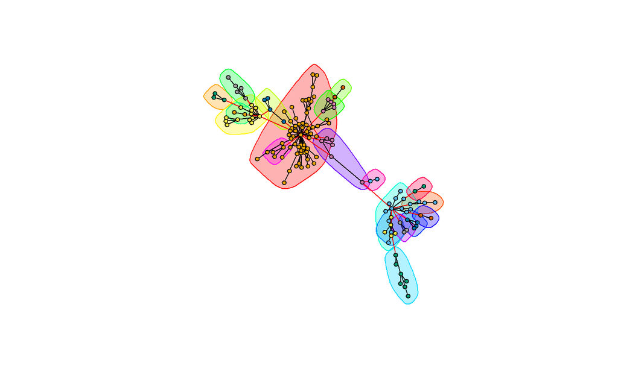

```r
plot(lb, Red_popart, layout = layout, vertex.size = 4,
     vertex.label = NA, edge.arrow.size = .1, vertex.color="gray50")
```

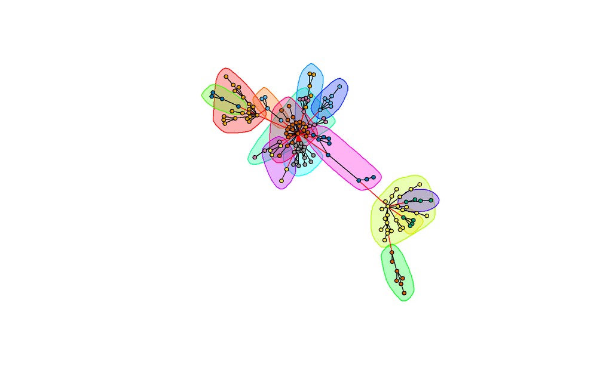

```r
plot(cs, Red_popart, layout = layout, vertex.size = 4,
     vertex.label = NA, edge.arrow.size = .1, vertex.color="gray50")
```

# 7 Conclusiones

Este es un análisis que puede brindar infomación acerca de como una variante podría estar distribuída en una población (implica analizar más secuencias)

Los resultados obtenidos con este análisis pueden ayudar a entender como es que las variantes virales se propagan, ademas, este tipo de redes geo-filogenéticas puede ser útil para observar la evolución viral en un sitio determinado.